# Learning about OHI scores

Erika Egg

## OH NO!

While you are working at your computer at NCEAS, you receive a frantic call from someone working on an OHI project:

THEY NEED HELP!

“No problem” you say, “I’ll get Melanie or Gage”…but they are no where to be found!

“Hold on, I’ll get Jamie or Casey or Courtney”…but they are also gone.

It is clearly going to be up to you to save the day!!

## You’ve got this!

Please help them answer the following questions. You will work from this document, using the code chunks as a work space to work explore the data. Do NOT bother keeping the code chunks neat and organized, we want to see your work process in all its messy glory. However, I DO recommend including plenty of comments, mostly because I have found this helps me organize my thoughts.

You can ask us any questions along the way (slack or issues)!

Good luck!

## Questions

### Getting the data

*Goal* Read the latest OHI global data into the R working space (call the data object “scores”).

*Hint* Here is a link to the data: https://raw.githubusercontent.com/OHI-Science/ohi-global/draft/eez/scores.csv

*Note* There are scores for 2023, you can ignore these. These are just here as a placeholder until we calculate new ones for 2023 (they are the 2022 scores).

### Region explore

*Hint 1* Here is a link to the official region list (the rgn_id column in this file matches the region_id column in the scores data): https://raw.githubusercontent.com/OHI-Science/ohi-global/draft/eez/spatial/regions_list.csv

*Hint 2* Here is a table that includes goal names: https://raw.githubusercontent.com/OHI-Science/ohi-global/draft/metadata_documentation/ohi_model/tables/ten_goals.csv

*Hint 3* Which region has all NA values for scores?

*Answer* Write your answer here!

**One region has all NAs for scores and is not included (Antarctica). Another region that seems to be not included is region ID 0 which has no corresponding region name in the official region list (it’s the overall index average score).**

*Question* Which region id corresponds to the United States?

```r
id_and_region %>%
  filter(region_name == "United States")
```

```
## # A tibble: 1 × 2
##   region_id region_name
##       <dbl> <chr>
## 1       163 United States
```

**Looking at my id_and_region table, we can see that 163 is the United States.**

### Goal explore

*Question* When I look at the number of goals, N=19 show up….I thought there were supposed to be 10 goals!!! Can you explain what all these are? Also, why do some of the goal abbreviations have 2 letters and others 3 letters?

*Hint 1* Review the methods doc here: https://raw.githack.com/OHI-Science/ohi-global/published/documents/methods/Supplement.html

*Answer* Write your answer here!

**There are 10 main goals and 8 subgoals (see Table 2.1 and 2.2 here for what each of these specifically are: https://raw.githack.com/OHI-Science/ohi-global/published/documents/methods/Supplement.html), with the last remaining number unaccounted for being “Index,” or the overall score for each region. Two letter abbreviations correspond to main goals, while three letter abbreviations correspond to subgoals.**

### Dimension explore

*Answer* Write your answer here!

### Missing data

*Question* Figure out which goals/subgoals have the most NA values for scores in 2022 (was 2021, changed it to update for this year). Which ones have the least? Can you discern any reason why some goals have lots of missing values and others do not?

*Hint* Include only dimension = score, and year = 2022, and cut region_id = 0.

*Answer* Write your answer here!

**CS, NP, and MAR have the most NA values for scores in 2022 (using number of NAs / total scores values ie. NA and non-NA, as a percent). Some countries don’t have carbon storing habitats, for example, which is why there are so many NAs. For mariculture, they may not have a mariculture industry.**

### Scores

*Question* If we have a goal with a future status of 80 and status of 90…what is the score?

*Hint* Isolate the future, status, and score values for one region and one goal and see if you can identify a pattern.

*Answer* Write your answer here!

**Score is an average of future & status values for one region and one goal. In the example, the score would be (80 + 90) / 2 = 85.**

### Metadata

*Project* Based on your data exploration and other resources, provide some metadata that describes each variable. Write it so it would be useful to you in the future as you are looking through these data.

Write it in the following table. NOTE: Knit the document to see if the table is formatting correctly (but don’t bother if you do not know how to knit a document or if you are running into errors!).

[output not shown]

### Plot

*Project* Create a scatterplot that compares 2012 and 2022 *scores* for each region for the artisanal opportunities goal. Based on this, do scores for the artisanal opportunities goal appear to have increased or decreased over time?

*Answer* Write your answer here!

**They appear to have increased, evidenced by the mean being higher in 2022. The lm lines also evidence this (if you uncomment that code instead of the mean lines).**

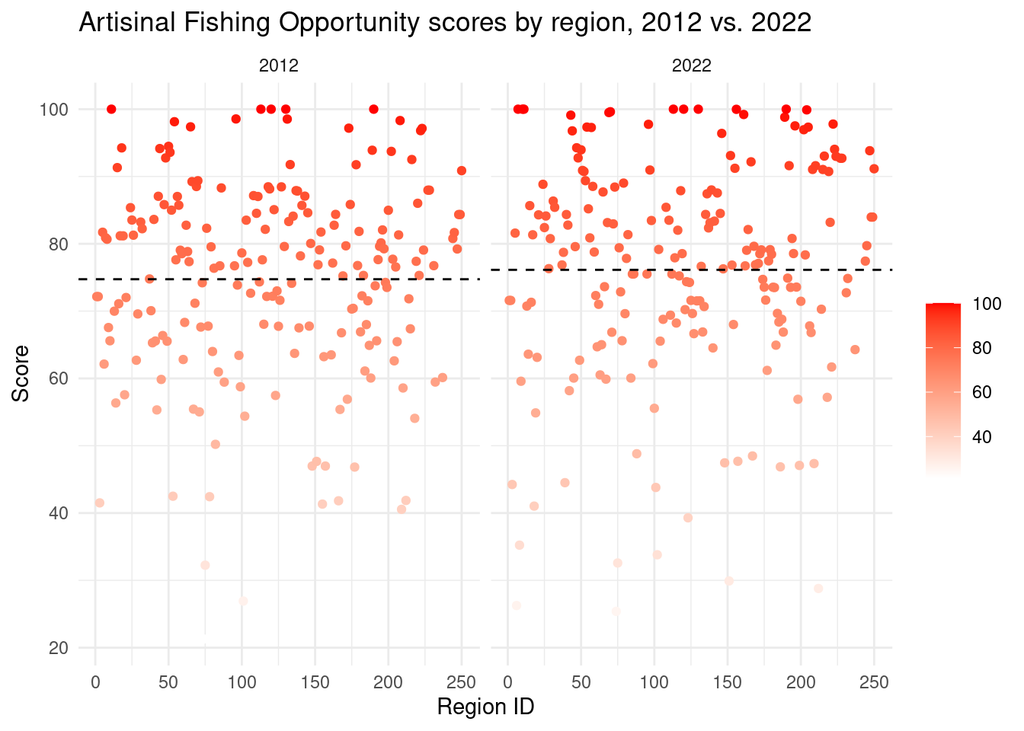

```r
## Working space
plot_1_df <- scores %>%
  filter(goal == "AO" & region_id != 0 & year %in% c(2012, 2022) & dimension == "score")

plot_1_df_means <- plot_1_df %>%
  group_by(year) %>%
  summarize(mean = mean(score, na.rm = TRUE))

plot1 <- ggplot(plot_1_df, aes(x = region_id, y = score)) +
  geom_point(aes(color = score)) +
  scale_color_gradient(low = "white",
                      high = "red") +
  facet_wrap(~year) +
  # geom_smooth(method = "lm", se = FALSE, color = "black") + # if you want lms instead
  geom_hline(data = plot_1_df_means, aes(yintercept = mean), linetype = "dashed") +
  theme_minimal() +
  labs(x = "Region ID",
       y = "Score",
       color = "",
       title = "Artisinal Fishing Opportunity scores by region, 2012 vs. 2022")

plot1
```

Create a plot that shows the distribution (e.g., histogram or barplot or ??) of *Index* scores of all countries.

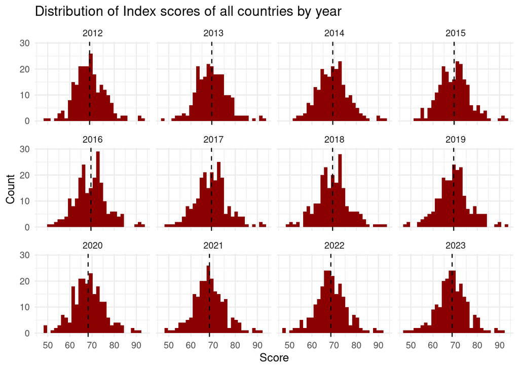

```r
## Code to create a plot showing distribution of country Index scores
# get a df for plotting
plot_2_df <- scores %>%
  filter(goal == "Index" & region_id != 0 & dimension == "score")

# get yearly mean scores
plot_2_df_means <- plot_2_df %>%
  group_by(year) %>%
  summarize(mean = mean(score, na.rm = TRUE))

# plot distributions faceted by year and include mean score by year
plot2 <- ggplot(plot_2_df, aes(y = score)) +
  geom_histogram(fill = "darkred") +
  facet_wrap(~year) +
  geom_hline(data = plot_2_df_means, aes(yintercept = mean), linetype = "dashed") +
  coord_flip() +
  theme_minimal() +
  labs(x = "Count",
       y = "Score",
       title = "Distribution of Index scores of all countries by year")

plot2
```

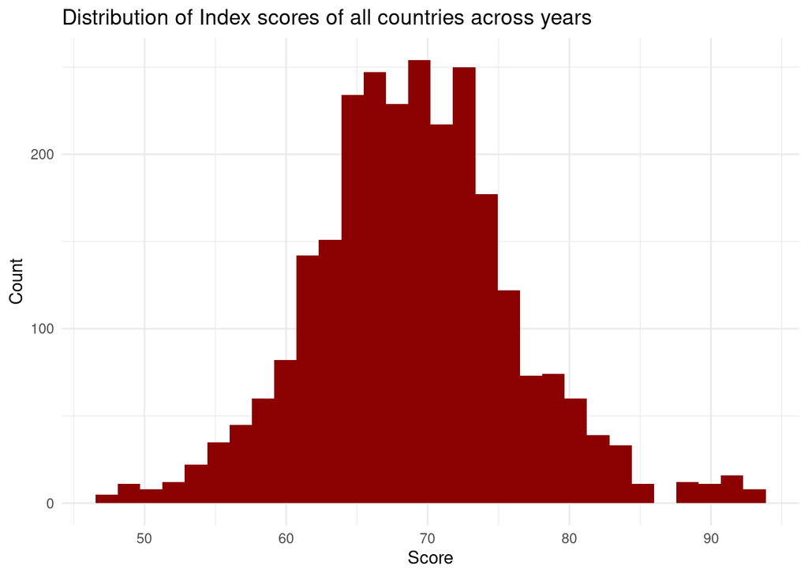

```r
# show without faceting by year too
plot3 <- ggplot(plot_2_df, aes(y = score)) +
  geom_histogram(fill = "darkred") +
  coord_flip() +
  theme_minimal() +
  labs(x = "Count",
       y = "Score",
       title = "Distribution of Index scores of all countries across years")

plot3
```